# Shortspine Thornyhead (SST) for the Pacific Coast of Canada: a DFO Case Study Operating model

Technical report for Fisheries and Oceans Canada

Quang Huynh, University of British Columbia q.huynh@oceans.ubc.ca

February 2019

# Introduction

This operating model was specified based on data and results from the 2015 assessment:

Starr, P.J., and Haigh, R. 2017. Stock assessment of the coastwide population of Shortspine Thornyhead (Sebastolobus alascanus) in 2015 off the British Columbia coast. Canadian Science Advisory Secretariat. Research Document 2017/015

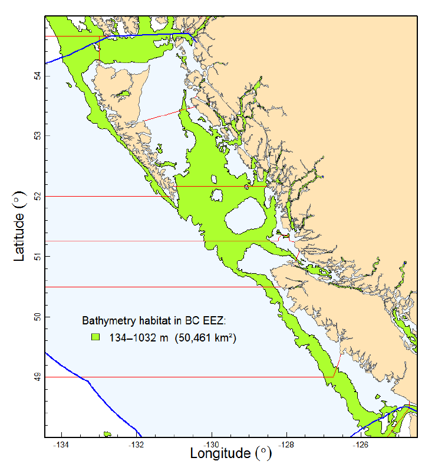

Coast of British Columbia (BC). Green area represents depth strata for SST habitat. Red boundaries define the Pacific Marine Fisheries Commission (PMFC) management areas.

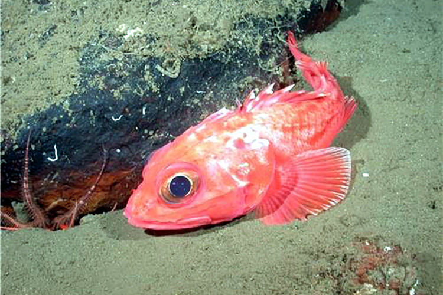

Shortspine Thornyhead (SST) specimen (image from NOAA Photo Library).

# Operating Model

The OM rdata file can be downloaded from here

Download and import into R using `myOM <- readRDS('OM.rdata')`

## Species Information

**Species**: *Sebastolobus alascanus*

**Common Name**: *Shortspine Thornyhead*

**Management Agency**: DFO

**Region**: British Columbia, Canada

**Latitude**: 48.1, 48.5, 54.6, 54.5

**Longitude**: -127, -125, -131, -135

## OM Parameters

**OM Name**: Name of the operating model: Stock:Shortspine Thornyhead Fleet: Obs model:Generic_Obs Imp model:Perfect_Imp

**proyears**: The number of projected years: 50

**interval**: The assessment interval - how often would you like to update the management system? 3

**pstar**: The percentile of the sample of the management recommendation for each method: 0.5

**maxF**: Maximum instantaneous fishing mortality rate that may be simulated for any given age class: 3

**reps**: Number of samples of the management recommendation for each method. Note that when this is set to 1, the mean value of the data inputs is used. 1

**Source**: A reference to a website or article from which parameters were taken to define the operating model

Data from 2015 Stock Assessment document

# Custom Parameters

Estimates of recruitment deviations from 1980-2015 from the assessment were incorporated into the operating model. The assessment used a delay-diference model with recruitment at age-16. Since the age-structured operating model specifies recruitment at age-1, the year of recruitment estimates were shifted back 15 years.

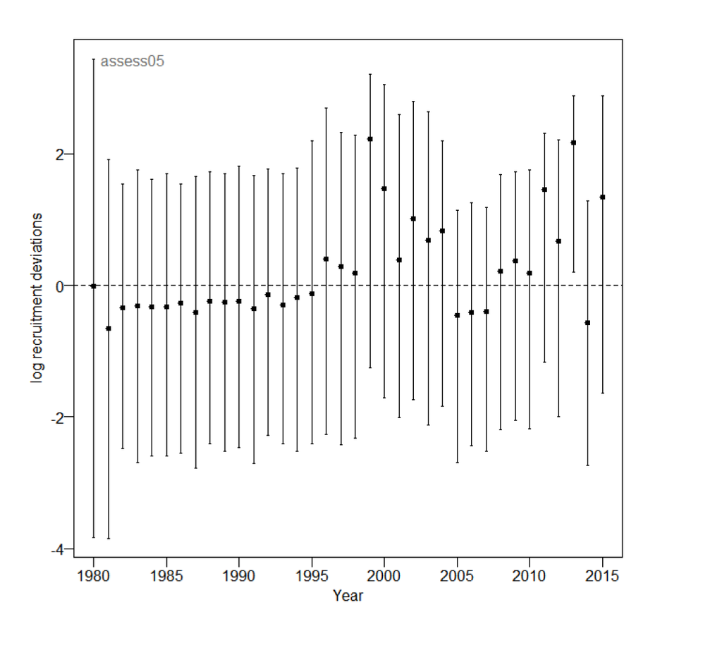

Posterior means and 95% credibility interavals of the logarithm of the recruitment deviations from the delay-difference model (image taken from Starr and Haigh, 2017).

# Stock Parameters

### Mortality and age: maxage, R0, M, Msd

**maxage**: The maximum age of individuals that is simulated (there is no plus group ). Single value. Positive integer

Specified Value(s): 95

The oldest observed fish in the DFO database is 95 years.

**R0**: The magnitude of unfished recruitment. Single value. Positive real number

Specified Value(s): 1000

An arbitrary value was used for scaling the population in the operating model. The assessment was not considered robust enough to provide absolute biomass estimates.

**M**: Natural mortality rate. Uniform distribution lower and upper bounds. Positive real number

Specified Value(s): 0.03, 0.12

The assessment used M = 0.08 (age-invariant) as the most plausible value. Alternative values ranging from 0.03 to 0.12 were also considered.

**Msd**: Inter-annual variability in natural mortality rate expressed as a coefficient of variation. Uniform distribution lower and upper bounds. Non-negative real numbers

Specified Value(s): 0, 0

We assumed time-invariant M.

### Natural Mortality Parameters

#### Sampled Parameters

Histograms of simulations of `M`, and `Msd` parameters, with vertical colored lines indicating 3 randomly drawn values used in other plots:

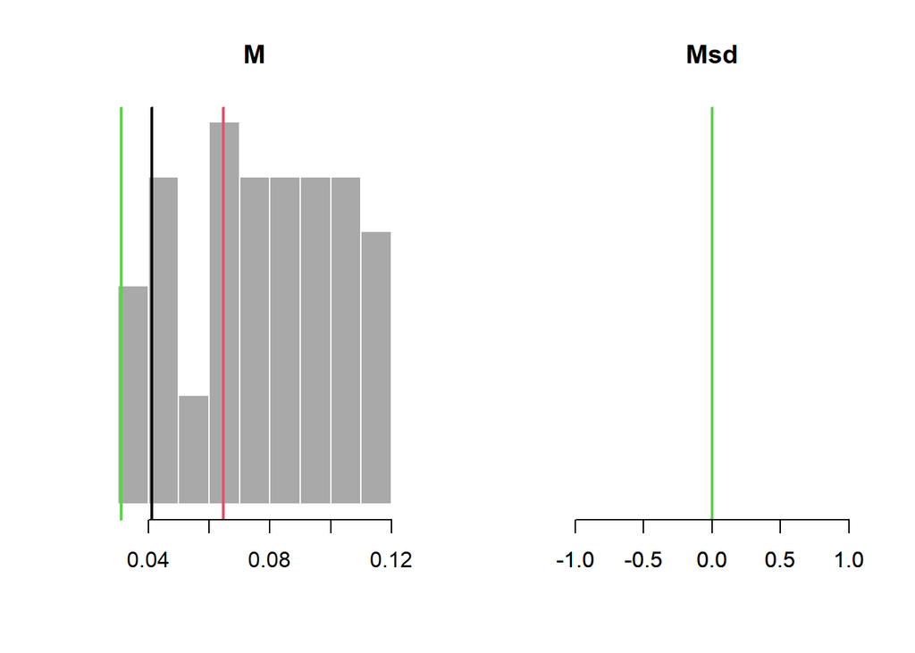

#### Time-Series

The average natural mortality rate by year for adult fish for 3 simulations. The vertical dashed line indicates the end of the historical period:

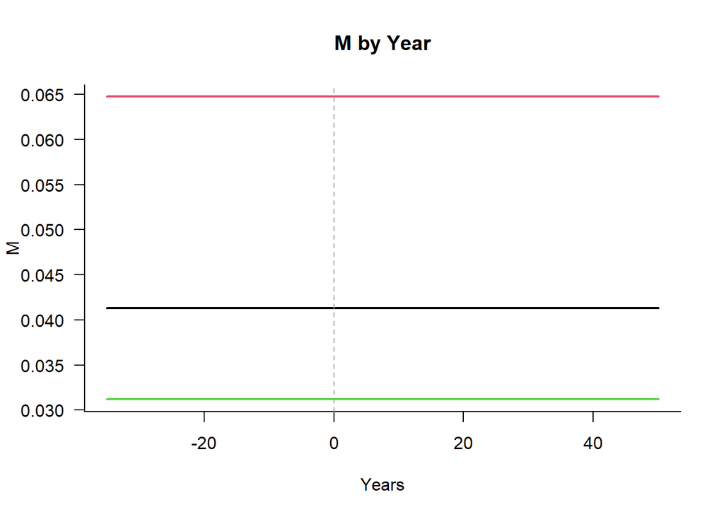

#### M-at-Age

Natural mortality-at-age for 3 simulations in the first historical year, the last historical year (i.e., current year), and the last projected year:

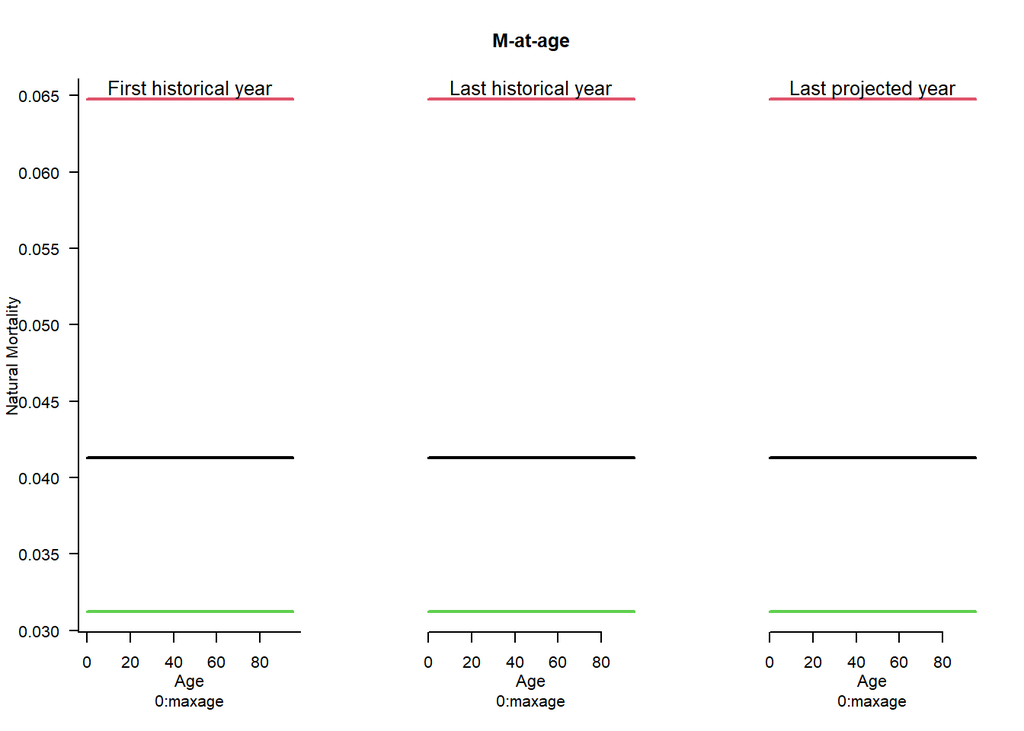

#### M-at-Length

Natural mortality-at-length for 3 simulations in the first historical year, the last historical year (i.e., current year), and the last projected year:

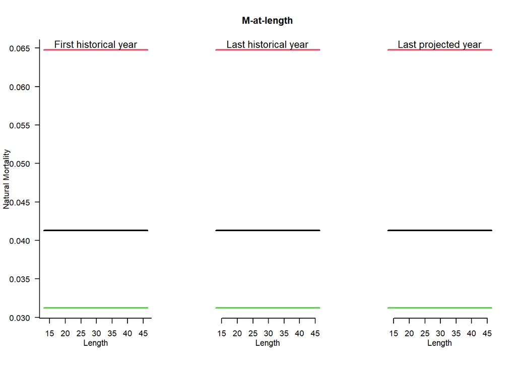

### Recruitment: h, SRrel, Perr, AC

**h**: Steepness of the stock recruit relationship. Uniform distribution lower and upper bounds. Values from 1/5 to 1

Specified Value(s): 0.55, 0.85

A range of steepness

**SRrel**: Type of stock-recruit relationship. Single value, switch (1) Beverton-Holt (2) Ricker. Integer

Specified Value(s): 1

A value of 1 represents the Beverton-Holt stock recruitment curve which is commonly used for BC groundfish.

**Perr**: Process error, the CV of log-normal recruitment deviations. Uniform distribution lower and upper bounds. Non-negative real numbers

Specified Value(s): 0.6, 0.6

The value of 0.6 for the standard deviation of the recruitment was used in the assessment and also used here.

**AC**: Auto-correlation in recruitment deviations rec(t)=AC*rec(t-1)+(1-AC)*sigma(t). Uniform distribution lower and upper bounds. Non-negative real numbers

Specified Value(s): 0, 0

This feature was not used in the operating model.

### Recruitment Parameters

#### Sampled Parameters

Histograms of 48 simulations of steepness (`h`), recruitment process error (`Perr`) and auto-correlation (`AC`) for the Beverton-Holt stock-recruitment relationship, with vertical colored lines indicating 3 randomly drawn values used in other plots:

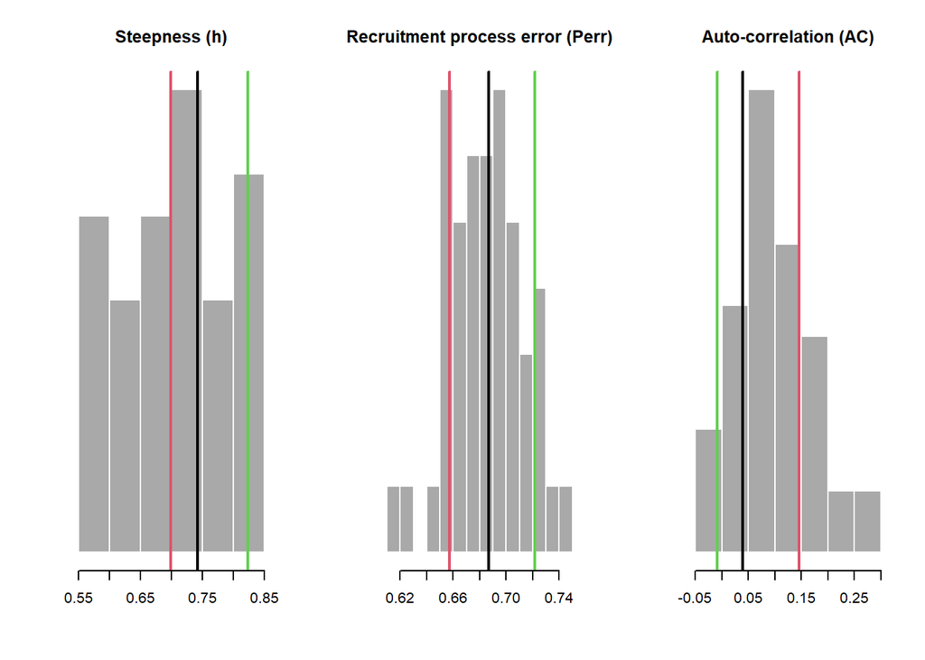

#### Time-Series

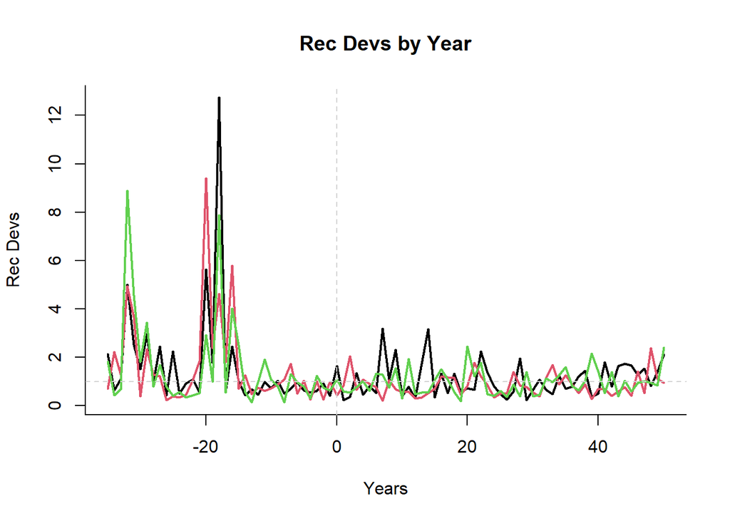

### Growth: Linf, K, t0, LenCV, Ksd, Linfsd

**Linf**: Maximum length. Uniform distribution lower and upper bounds. Positive real numbers

Specified Value(s): 47.2, 47.2

Growth estimates were obtained from the DFO groundfish database for the assessment. This is the value used for the assessment (Table E.1 of Starr and Haigh, 2017).

**K**: von Bertalanffy growth parameter k. Uniform distribution lower and upper bounds. Positive real numbers

Specified Value(s): 0.04, 0.04

This is the value reported in the assessment (Table E.1 of Starr and Haigh, 2017).

**t0**: von Bertalanffy theoretical age at length zero. Uniform distribution lower and upper bounds. Non-positive real numbers

Specified Value(s): -8.46, -8.46

This is the value reported in the assessment (Table E.1 of Starr and Haigh, 2017).

**LenCV**: Coefficient of variation of length-at-age (assumed constant for all age classes). Uniform distribution lower and upper bounds. Positive real numbers

Specified Value(s): 0.1, 0.1

In the absence of length at age data I assume this to be 10%.

**Ksd**: Inter-annual variability in growth parameter k expressed as coefficient of variation. Uniform distribution lower and upper bounds. Non-negative real numbers

Specified Value(s): 0, 0

No variability in growth is assumed here.

**Linfsd**: Inter-annual variability in maximum length expressed as a coefficient of variation. Uniform distribution lower and upper bounds. Non-negative real numbers

Specified Value(s): 0, 0

No variability in growth is assumed here.

### Growth Parameters

#### Sampled Parameters

Histograms of simulations of von Bertalanffy growth parameters `Linf`, `K`, and `t0`, and inter-annual variability in Linf and K (`Linfsd` and `Ksd`), with vertical colored lines indicating 3 randomly drawn values used in other plots:

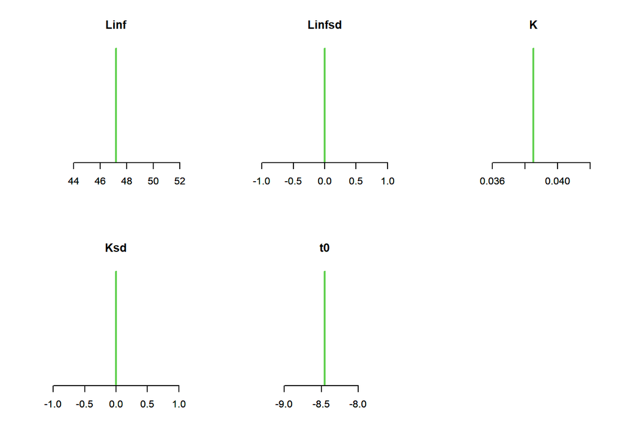

#### Time-Series

The Linf and K parameters in each year for 3 simulations. The vertical dashed line indicates the end of the historical period:

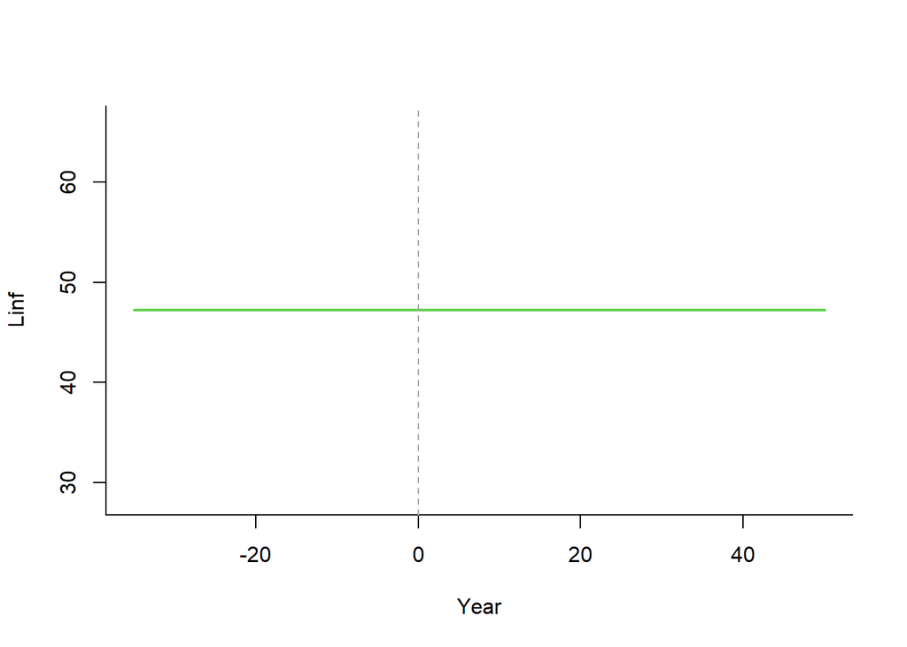

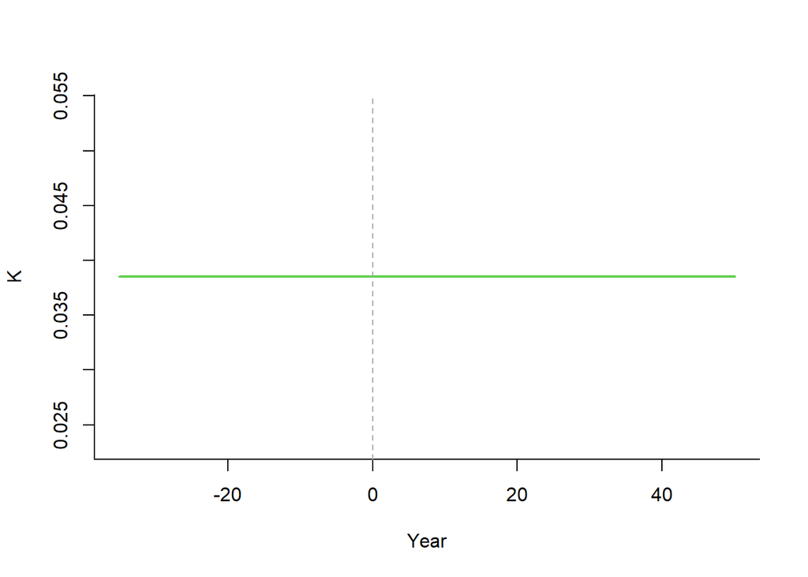

#### Growth Curves

Sampled length-at-age curves for 3 simulations in the first historical year, the last historical year, and the last projection year.

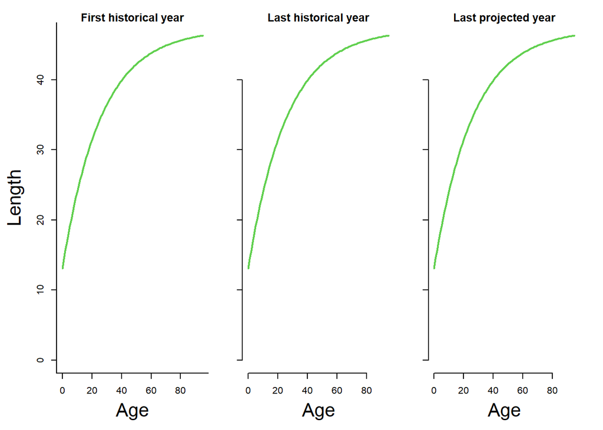

### Maturity: L50, L50_95

**L50**: Length at 50 percent maturity. Uniform distribution lower and upper bounds. Positive real numbers

Specified Value(s): 21.25, 21.25

Value taken from Figure D.11 of Starr and Haigh (2017).

**L50_95**: Length increment from 50 percent to 95 percent maturity. Uniform distribution lower and upper bounds. Positive real numbers

Specified Value(s): 5, 5

Value taken from Figure D.11 of Starr and Haigh (2017).

### Maturity Parameters

#### Sampled Parameters

Histograms of simulations of `L50` (length at 50% maturity), `L95` (length at 95% maturity), and corresponding derived age at maturity parameters (`A50` and `A95`), with vertical colored lines indicating 3 randomly drawn values used in other plots:

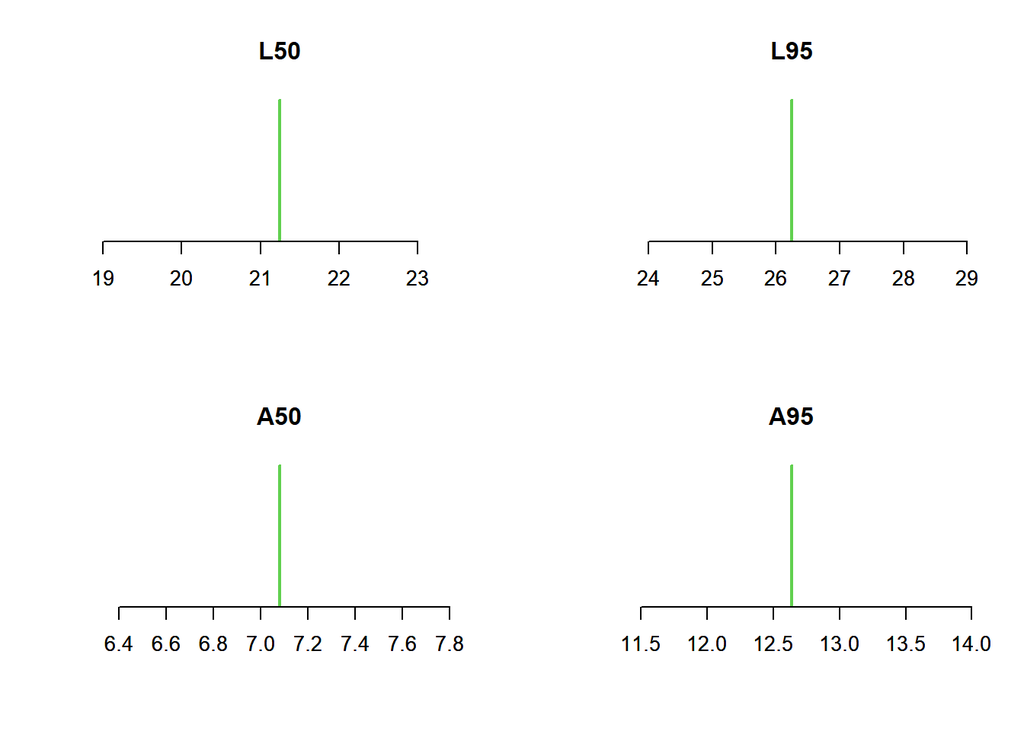

#### Maturity at Age and Length

Maturity-at-age and -length for 3 simulations in the first historical year, the last historical year (i.e., current year), and the last projected year:

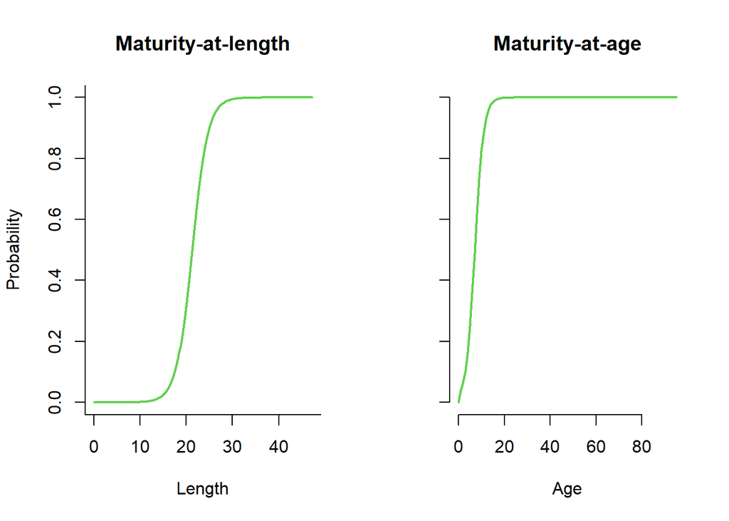

### Stock depletion and Discard Mortality: D, Fdisc

**D**: Current level of stock depletion SSB(current)/SSB(unfished). Uniform distribution lower and upper bounds. Fraction

Specified Value(s): 0.83, 1.85

Range of values taken from the assessment.

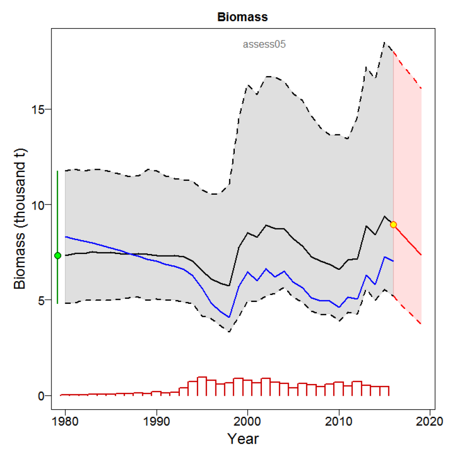

Biomass depletion estimated from the 2015 assessment.

**Fdisc**: Fraction of discarded fish that die. Uniform distribution lower and upper bounds. Non-negative real numbers

Specified Value(s): 0.9, 1

Very discard mortality rate is assumed due to life history of rockfish.

### Depletion and Discard Mortality

#### Sampled Parameters

Histograms of simulations of depletion (spawning biomass in the last historical year over average unfished spawning biomass; `D`) and the fraction of discarded fish that are killed by fishing mortality (`Fdisc`), with vertical colored lines indicating 3 randomly drawn values.

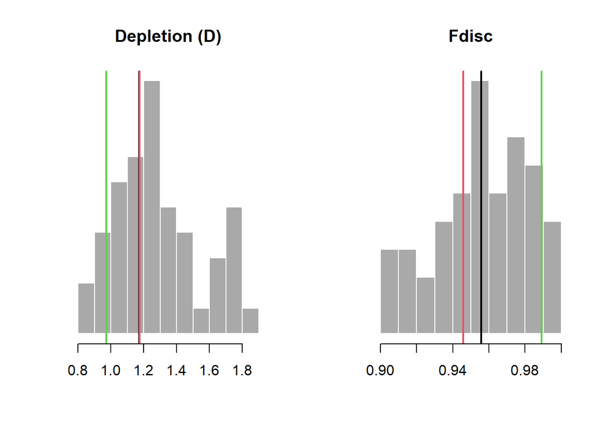

### Length-weight conversion parameters: a, b

**a**: Length-weight parameter alpha. Single value. Positive real number

Specified Value(s): 0

This is the value reported in the assessment (Table E.1 of Starr and Haigh, 2017).

**b**: Length-weight parameter beta. Single value. Positive real number

Specified Value(s): 3.17

This is the value reported in the assessment (Table E.1 of Starr and Haigh, 2017).

### Spatial distribution and movement: Size_area_1, Frac_area_1, Prob_staying

**Size_area_1**: The size of area 1 relative to area 2. Uniform distribution lower and upper bounds. Positive real numbers

Specified Value(s): 0.5, 0.5

No justification provided.

**Frac_area_1**: The fraction of the unfished biomass in stock 1. Uniform distribution lower and upper bounds. Positive real numbers

Specified Value(s): 0.5, 0.5

A fully mixed stock is simulated.

**Prob_staying**: The probability of individuals in area 1 remaining in area 1 over the course of one year. Uniform distribution lower and upper bounds. Positive fraction.

Specified Value(s): 0.5, 0.5

A fully mixed stock is simulated.

### Spatial & Movement

#### Sampled Parameters

Histograms of 48 simulations of size of area 1 (`Size_area_1`), fraction of unfished biomass in area 1 (`Frac_area_1`), and the probability of staying in area 1 in a year (`Frac_area_1`), with vertical colored lines indicating 3 randomly drawn values used in other plots:

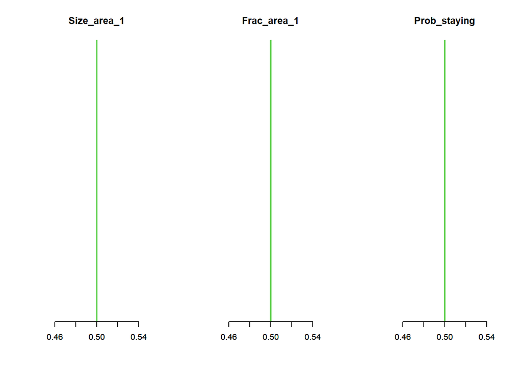

# Fleet Parameters

### Historical years of fishing, spatial targeting: nyears, Spat_targ

**nyears**: The number of years for the historical spool-up simulation. Single value. Positive integer

Specified Value(s): 36

1980-2015, a total of 36 years.

**Spat_targ**: Distribution of fishing in relation to spatial biomass: fishing distribution is proportional to B^Spat_targ. Uniform distribution lower and upper bounds. Real numbers

Specified Value(s): 1, 1

No spatial targetting is assumed since SST is often incidential catch in the BC groundfish fishery (Starr and Haigh, 2017).

### Trend in historical fishing effort (exploitation rate), interannual variability in fishing effort: EffYears, EffLower, EffUpper, Esd

**EffYears**: Years representing join-points (vertices) of time-varying effort. Vector. Non-negative real numbers

Posterior distribution of F in the assessment was used to bound historical effort in the operating model.

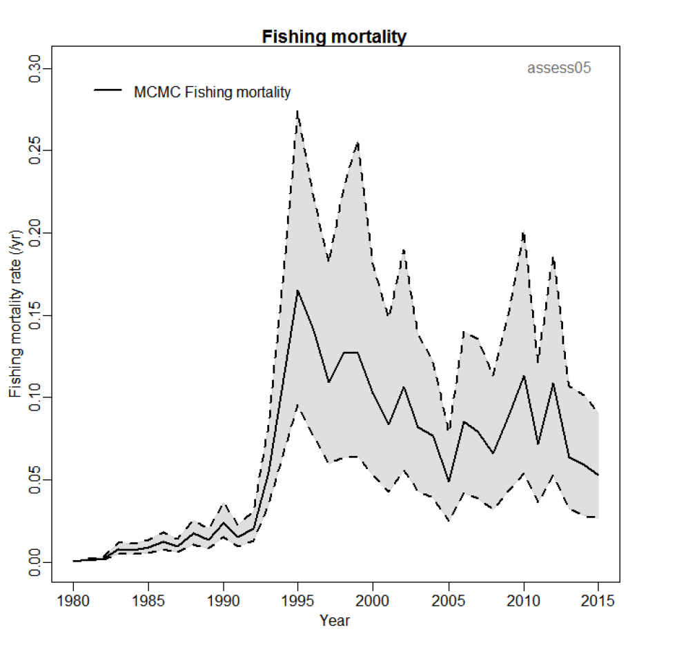

Posterior distribution of fishing mortality estimated from the 2015 assessment.

**EffLower**: Lower bound on relative effort corresponding to EffYears. Vector. Non-negative real numbers

The 95% credibility interval of F in the assessment was used to bound historical effort in the operating model.

**EffUpper**: Upper bound on relative effort corresponding to EffYears. Vector. Non-negative real numbers

The 95% credibility interval of F in the assessment was used to bound historical effort in the operating model.

| EffYears | EffLower | EffUpper |
| --- | --- | --- |
| 1980 | 0.00000 | 0.00126 |
| 1981 | 0.00084 | 0.00374 |
| 1982 | 0.00210 | 0.00330 |
| 1983 | 0.00420 | 0.01250 |
| 1984 | 0.00462 | 0.01160 |
| 1985 | 0.00588 | 0.01410 |
| 1986 | 0.00798 | 0.01790 |
| 1987 | 0.00588 | 0.01490 |
| 1988 | 0.01010 | 0.02540 |
| 1989 | 0.00882 | 0.02240 |
| 1990 | 0.01470 | 0.03620 |
| 1991 | 0.00966 | 0.02400 |
| 1992 | 0.01340 | 0.03070 |
| 1993 | 0.02900 | 0.06840 |
| 1994 | 0.05880 | 0.15000 |
| 1995 | 0.09410 | 0.27400 |
| 1996 | 0.07650 | 0.21400 |
| 1997 | 0.06010 | 0.18400 |
| 1998 | 0.06430 | 0.21800 |
| 1999 | 0.06430 | 0.25500 |
| 2000 | 0.05210 | 0.18000 |
| 2001 | 0.04290 | 0.15200 |
| 2002 | 0.05590 | 0.19000 |
| 2003 | 0.04410 | 0.13700 |
| 2004 | 0.03870 | 0.12300 |
| 2005 | 0.02560 | 0.08150 |
| 2006 | 0.04160 | 0.14100 |
| 2007 | 0.03870 | 0.13600 |
| 2008 | 0.03320 | 0.11600 |
| 2009 | 0.04330 | 0.15000 |
| 2010 | 0.05380 | 0.19800 |
| 2011 | 0.03660 | 0.12300 |
| 2012 | 0.05340 | 0.18600 |
| 2013 | 0.03570 | 0.10700 |
| 2014 | 0.02820 | 0.10300 |
| 2015 | 0.02650 | 0.09090 |

**Esd**: Additional inter-annual variability in fishing mortality rate. Uniform distribution lower and upper bounds. Non-negative real numbers

Specified Value(s): 0.1, 0.1

A generic value of 0.1 was used.

### Historical Effort

#### Sampled Parameters

Histograms of 48 simulations of inter-annual variability in historical fishing mortality (`Esd`), with vertical colored lines indicating 3 randomly drawn values used in the time-series plot:

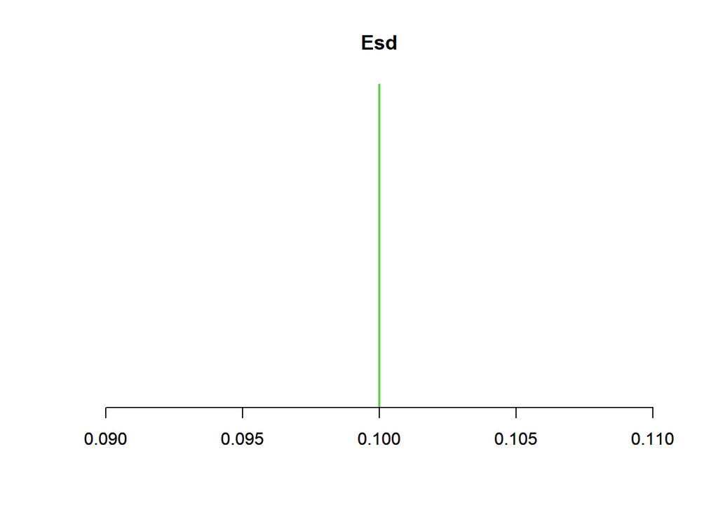

#### Time-Series

Time-series plot showing 3 trends in historical fishing mortality (`OM@EffUpper` and `OM@EffLower` or `OM@cpars$Find`):

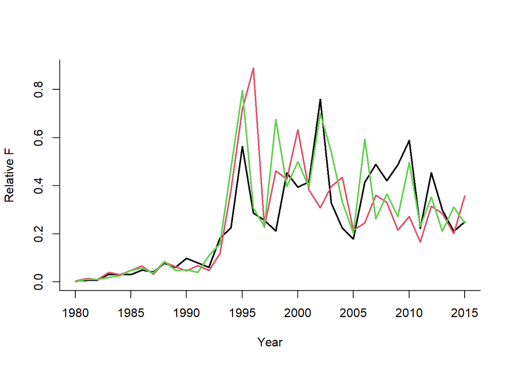

### Annual increase in catchability, interannual variability in catchability: qinc, qcv

**qinc**: Average percentage change in fishing efficiency (applicable only to forward projection and input controls). Uniform distribution lower and upper bounds. Non-negative real numbers

Specified Value(s): 0, 0

Trend in fishing efficiency (projections). In the future, is a unit of effort going to lead to higher fishing mortality (positive qinc) or lower fishing mortality (negative qinc). Since SST is often an incidential catch species, no future changes in efficiency is modelled.

**qcv**: Inter-annual variability in fishing efficiency (applicable only to forward projection and input controls). Uniform distribution lower and upper bounds. Non-negative real numbers

Specified Value(s): 0.1, 0.1

Some background interannual variability in catchability is modeled (10%).

### Future Catchability

#### Sampled Parameters

Histograms of 48 simulations of inter-annual variability in fishing efficiency (`qcv`) and average annual change in fishing efficiency (`qinc`), with vertical colored lines indicating 3 randomly drawn values used in the time-series plot:

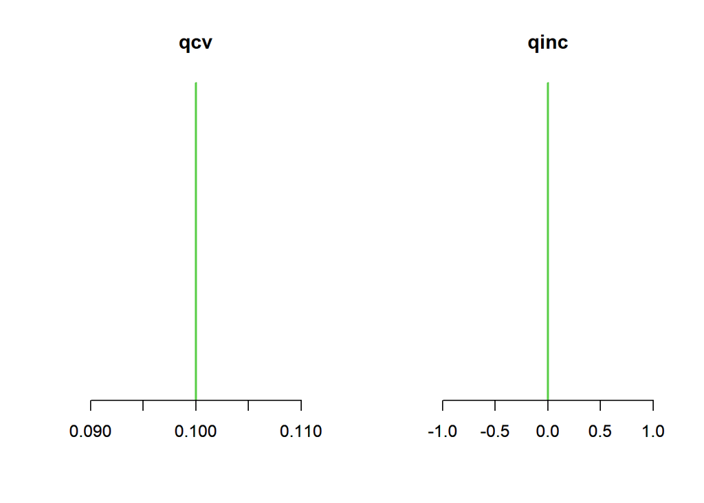

#### Time-Series

Time-series plot showing 3 trends in future fishing efficiency (catchability):

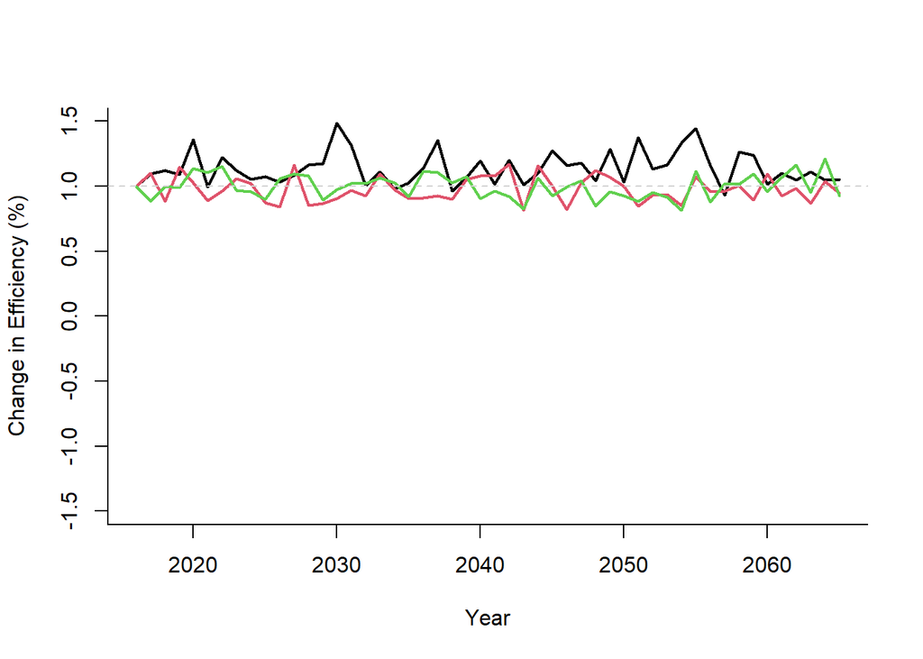

### Fishery gear length selectivity: L5, LFS, Vmaxlen, isRel

**L5**: Shortest length corresponding to 5 percent vulnerability. Uniform distribution lower and upper bounds. Positive real numbers

Specified Value(s): 15, 20

Based on cumulative length distributions of samples from the commercial fishery, the smallest animals caught are in the 15-20 cm range.

**LFS**: Shortest length that is fully vulnerable to fishing. Uniform distribution lower and upper bounds. Positive real numbers

Specified Value(s): 25, 30

Full selectivity is assumed at age 16 in the assessment model. Considering the growth curve, this length range represents age-16 animals.

**Vmaxlen**: The vulnerability of fish at Stock@Linf . Uniform distribution lower and upper bounds. Fraction

Specified Value(s): 1, 1

We follow the delay-difference assessment model assumption of flat-topped selectivity of old animals.

**isRel**: Selectivity parameters in units of size-of-maturity (or absolute eg cm). Single value. Boolean

Specified Value(s): FALSE

Selectivity is in terms of absolute length, not relative to length at maturity.

### Fishery length retention: LR5, LFR, Rmaxlen, DR

**LR5**: Shortest length corresponding ot 5 percent retention. Uniform distribution lower and upper bounds. Non-negative real numbers

Specified Value(s): 0, 0

Retention follows selectivity.

**LFR**: Shortest length that is fully retained. Uniform distribution lower and upper bounds. Non-negative real numbers

Specified Value(s): 0, 0

Retention follows selectivity.

**Rmaxlen**: The retention of fish at Stock@Linf . Uniform distribution lower and upper bounds. Non-negative real numbers

Specified Value(s): 1, 1

Retention follows selectivity.

**DR**: Discard rate - the fraction of caught fish that are discarded. Uniform distribution lower and upper bounds. Fraction

Specified Value(s): 0, 0

With 100% monitoring of the BC groundfish fishery, all discards are assumed to be accounted for.

### Current Year: CurrentYr

**CurrentYr**: The current calendar year (final year) of the historical simulations (eg 2011). Single value. Positive integer

Specified Value(s): 2015

The terminal year of the assessment was used.

### Existing Spatial Closures: MPA

**MPA**: Is Area 1 currently closed (TRUE) or open (FALSE)? Defaults to FALSE

Specified Value(s): FALSE

No justification provided.

# Obs Parameters

The observation model parameters are taken from the `Generic_Obs` object subject to a few additional changes which are documented here.

### Catch statistics: Cobs, Cbiascv, CAA_nsamp, CAA_ESS, CAL_nsamp, CAL_ESS

**Cobs**: Log-normal catch observation error expressed as a coefficient of variation. Uniform distribution lower and upper bounds. Non-negative real numbers

Specified Value(s): 0.1, 0.3

As `Generic_Obs`.

**Cbiascv**: Log-normal coefficient of variation controlling the sampling of bias in catch observations for each simulation. Single value. Non-negative real number

Specified Value(s): 0.1

As `Generic_Obs`.

**CAA_nsamp**: Number of catch-at-age observation per time step. Uniform distribution lower and upper bounds. Positive real numbers

Specified Value(s): 100, 200

As `Generic_Obs`. Age composition data do not seem to be collected regularly. Thus, this operating model can be used to evaluate the value of collecting annual age comps.

**CAA_ESS**: Effective sample size (independent age draws) of the multinomial catch-at-age observation error model. Uniform distribution lower and upper bounds. Positive integers

Specified Value(s): 25, 50

As `Generic_Obs`. Age composition data do not seem to be collected regularly. Thus, this operating model can be used to evaluate the value of collecting annual age comps.

**CAL_nsamp**: Number of catch-at-length observation per time step. Uniform distribution lower and upper bounds. Positive integers

Specified Value(s): 1500, 2000

Approximately 32,000 length samples were recorded from the DFO groundfish database from 1998-2014. This averages around 1,800 per year.

**CAL_ESS**: Effective sample size (independent length draws) of the multinomial catch-at-length observation error model. Uniform distribution lower and upper bounds. Positive integers

Specified Value(s): 25, 50

As `Generic_Obs`. The effective sample size is usually smaller than the nominal sample size.

### Index imprecision, bias and hyperstability: Iobs, Btobs, Btbiascv, beta

**Iobs**: Observation error in the relative abundance indices expressed as a coefficient of variation. Uniform distribution lower and upper bounds. Positive real numbers

Specified Value(s): 0.1, 0.4

As `Generic_Obs`.

**Btobs**: Log-normal coefficient of variation controlling error in observations of current stock biomass among years. Uniform distribution lower and upper bounds. Positive real numbers

Specified Value(s): 0.2, 0.5

As `Generic_Obs`.

**Btbiascv**: Uniform-log bounds for sampling persistent bias in current stock biomass. Uniform-log distribution lower and upper bounds. Positive real numbers

Specified Value(s): 0.33, 3

As `Generic_Obs`.

**beta**: A parameter controlling hyperstability/hyperdepletion where values below 1 lead to hyperstability (an index that decreases slower than true abundance) and values above 1 lead to hyperdepletion (an index that decreases more rapidly than true abundance). Uniform distribution lower and upper bounds. Positive real numbers

Specified Value(s): 0.67, 1.5

Since the survey is carried out according to a systematic design, we assume that it varies roughly proportionally to real abundance and specify a beta parameter between 2/3 and 3/2.

### Bias in maturity, natural mortality rate and growth parameters: LenMbiascv, Mbiascv, Kbiascv,t0biascv, Linfbiascv

**LenMbiascv**: Log-normal coefficient of variation for sampling persistent bias in length at 50 percent maturity. Single value. Positive real numbers

Specified Value(s): 0.1

As `Generic_Obs`.

**Mbiascv**: Log-normal coefficient of variation for sampling persistent bias in observed natural mortality rate. Single value. Positive real number

Specified Value(s): 0.2

As `Generic_Obs`.

**Kbiascv**: Log-normal coefficient of variation for sampling persistent bias in observed growth parameter K. Single value. Positive real number

Specified Value(s): 0.1

As `Generic_Obs`.

**t0biascv**: Log-normal coefficient of variation for sampling persistent bias in observed t0. Single value. Positive real number

Specified Value(s): 0.1

As `Generic_Obs`.

**Linfbiascv**: Log-normal coefficient of variation for sampling persistent bias in observed maximum length. Single value. Positive real number

Specified Value(s): 0.05

As `Generic_Obs`.

### Bias in length at first capture, length at full selection: LFCbiascv, LFSbiascv

**LFCbiascv**: Log-normal coefficient of variation for sampling persistent bias in observed length at first capture. Single value. Positive real number

Specified Value(s): 0.05

As `Generic_Obs`.

**LFSbiascv**: Log-normal coefficient of variation for sampling persistent bias in length-at-full selection. Single value. Positive real number

Specified Value(s): 0.05

As `Generic_Obs`.

### Bias in fishery reference points, unfished biomass, FMSY, FMSY/M ratio, biomass at MSY relative to unfished: FMSY_Mbiascv, BMSY_B0biascv

**FMSY_Mbiascv**: Log-normal coefficient of variation for sampling persistent bias in FMSY/M. Single value. Positive real number

Specified Value(s): 0.2

As `Generic_Obs`.

**BMSY_B0biascv**: Log-normal coefficient of variation for sampling persistent bias in BMSY relative to unfished. Single value. Positive real number

Specified Value(s): 0.2

As `Generic_Obs`.

### Management targets in terms of the index (i.e., model free), the total annual catches and absolute biomass levels: Irefbiascv, Crefbiascv, Brefbiascv

**Irefbiascv**: Log-normal coefficient of variation for sampling persistent bias in relative abundance index at BMSY. Single value. Positive real number

Specified Value(s): 0.2

As `Generic_Obs`.

**Crefbiascv**: Log-normal coefficient of variation for sampling persistent bias in MSY. Single value. Positive real number

Specified Value(s): 0.2

As `Generic_Obs`.

**Brefbiascv**: Log-normal coefficient of variation for sampling persistent bias in BMSY. Single value. Positive real number

Specified Value(s): 0.5

As `Generic_Obs`.

### Depletion bias and imprecision: Dbiascv, Dobs

**Dbiascv**: Log-normal coefficient of variation for sampling persistent bias in stock depletion. Single value. Positive real number

Specified Value(s): 0.5

As `Generic_Obs`.

**Dobs**: Log-normal coefficient of variation controlling error in observations of stock depletion among years. Uniform distribution lower and upper bounds. Positive real numbers

Specified Value(s): 0.05, 0.1

As `Generic_Obs`.

### Recruitment compensation and trend: hbiascv, Recbiascv, sigmaRbiascv

**hbiascv**: Log-normal coefficient of variation for sampling persistent bias in steepness. Single value. Positive real number

Specified Value(s): 0.2

As `Generic_Obs`.

**Recbiascv**: Log-normal coefficient of variation for sampling persistent bias in recent recruitment strength. Uniform distribution lower and upper bounds. Positive real numbers

Specified Value(s): 0.1, 0.3

As `Generic_Obs`.

**sigmaRbiascv**: Log-normal coefficeint of variation for sampling persistent bias in recruitment variability. Single value. Positive real number

Specified Value(s): 0.1

No justification provided.

### Effort: Eobs, Ebiascv

**Eobs**: Log-normal effort observation error expressed as a coefficient of variation. Uniform distribution lower and upper bounds. Non-negative real numbers

Specified Value(s): 0.1, 0.3

No justification provided.

**Ebiascv**: Log-normal coefficient of variation controlling the sampling of bias in effort observations for each simulation. Single value. Non-negative real number

Specified Value(s): 0.1

No justification provided.

## Observation Parameters

### Catch Observations

#### Sampled Parameters

Histograms of 48 simulations of inter-annual variability in catch observations (`Csd`) and persistent bias in observed catch (`Cbias`), with vertical colored lines indicating 3 randomly drawn values used in other plots:

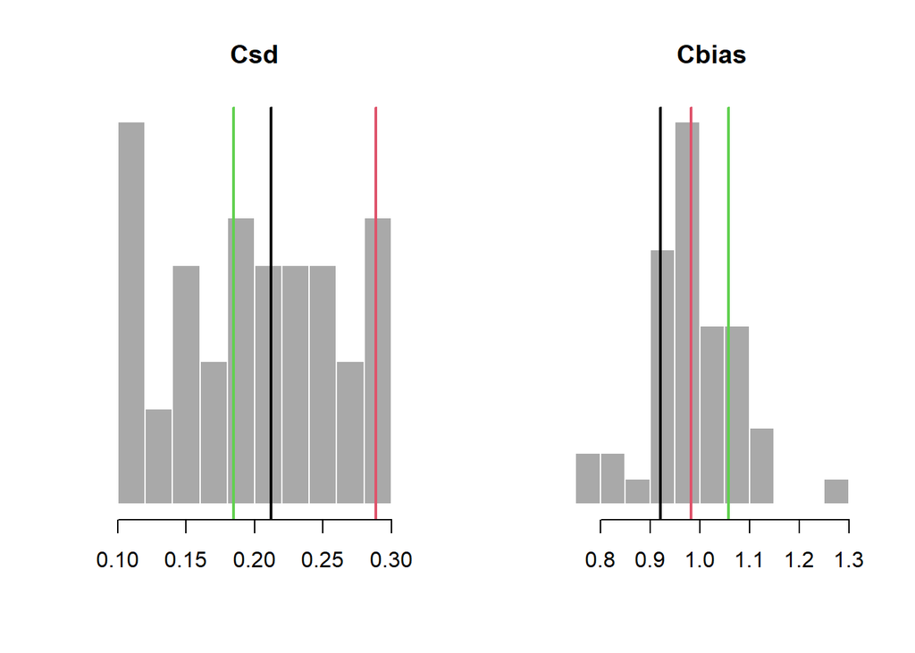

#### Time-Series

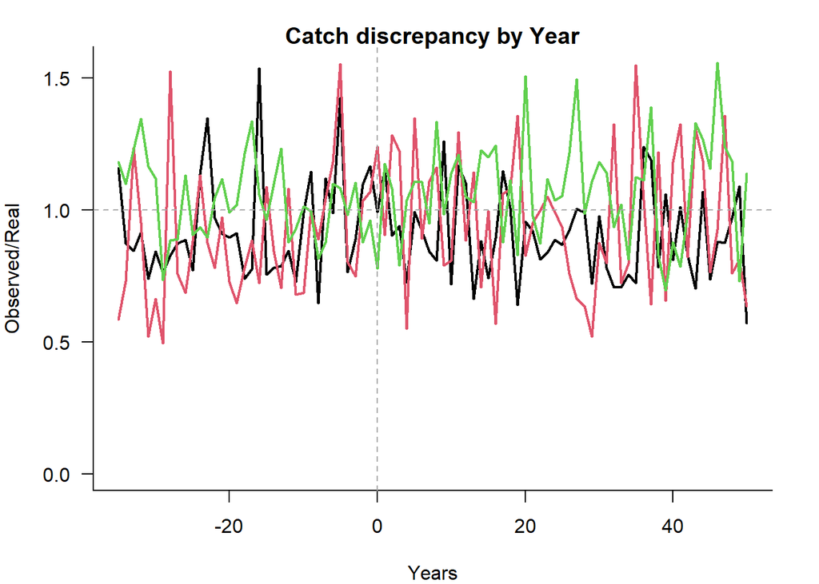

### Depletion Observations

#### Sampled Parameters

Histograms of 48 simulations of inter-annual variability in depletion observations (`Dobs`) and persistent bias in observed depletion (`Dbias`), with vertical colored lines indicating 3 randomly drawn values used in other plots:

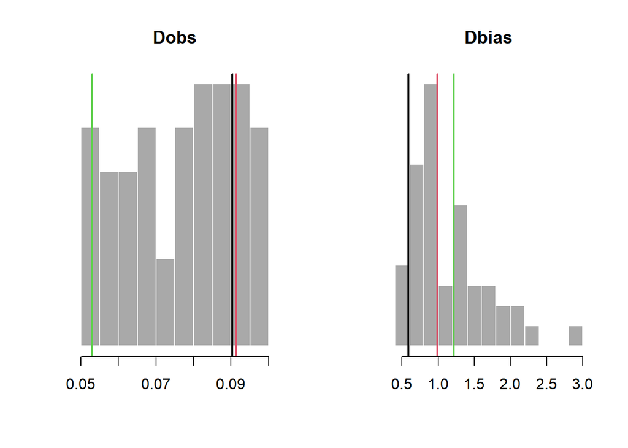

#### Time-Series

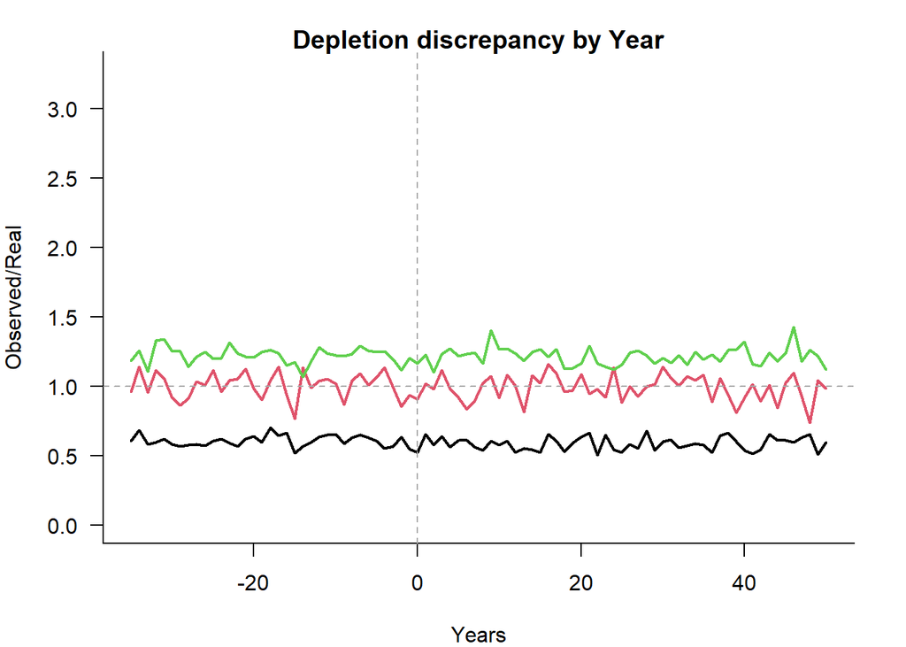

### Abundance Observations

#### Sampled Parameters

Histograms of 48 simulations of inter-annual variability in abundance observations (`Btobs`) and persistent bias in observed abundance (`Btbias`), with vertical colored lines indicating 3 randomly drawn values used in other plots:

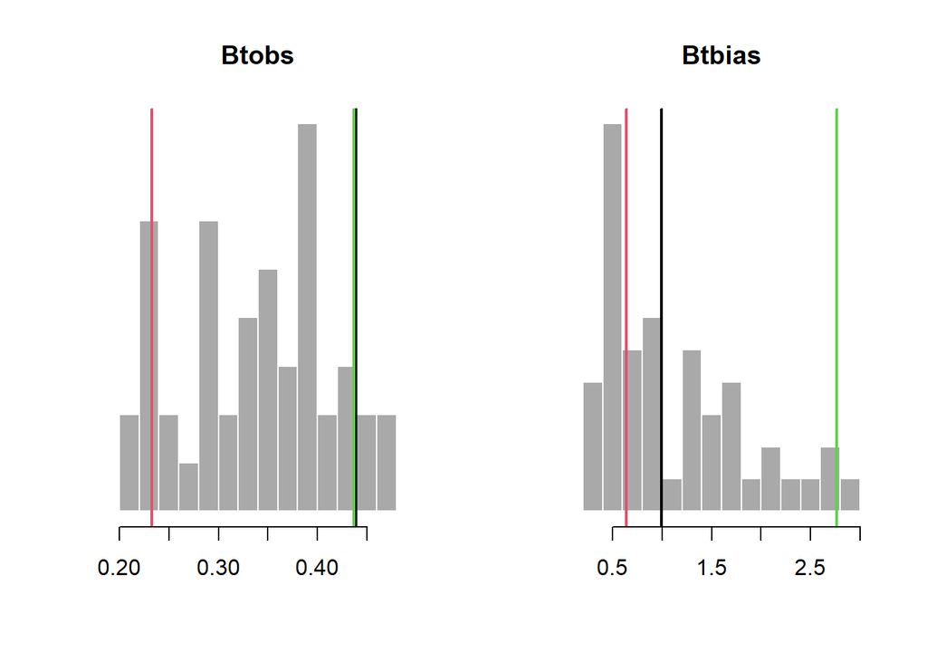

#### Time-Series

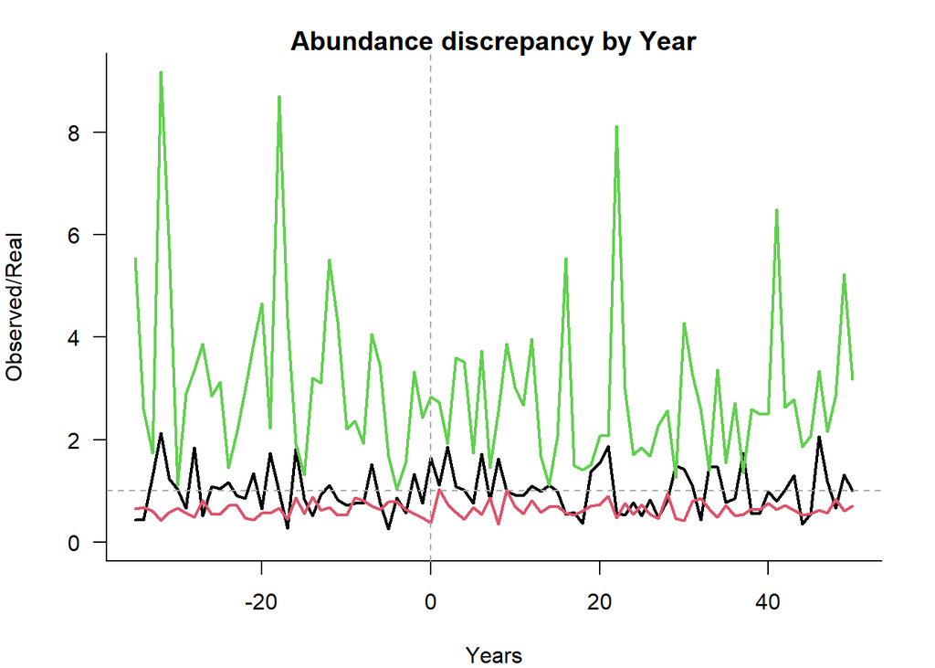

### Index Observations

#### Sampled Parameters

Histograms of 48 simulations of inter-annual variability in index observations (`Iobs`) and hyper-stability/depletion in observed index (`beta`), with vertical colored lines indicating 3 randomly drawn values used in other plots:

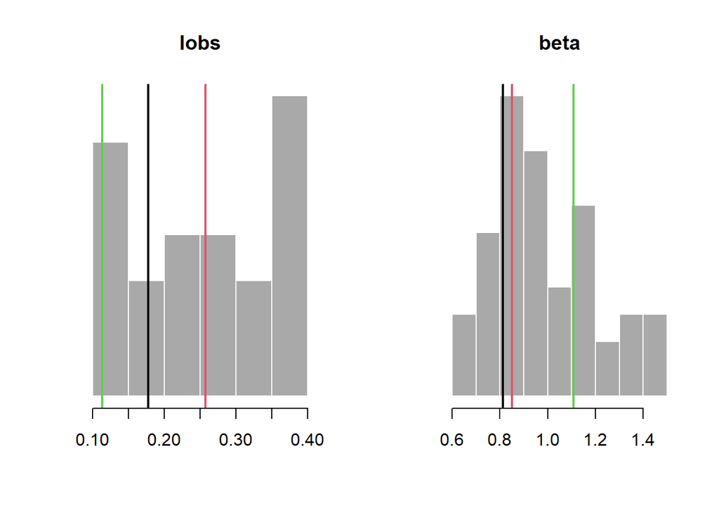

#### Time-Series

Time-series plot of 3 samples of index observation error:

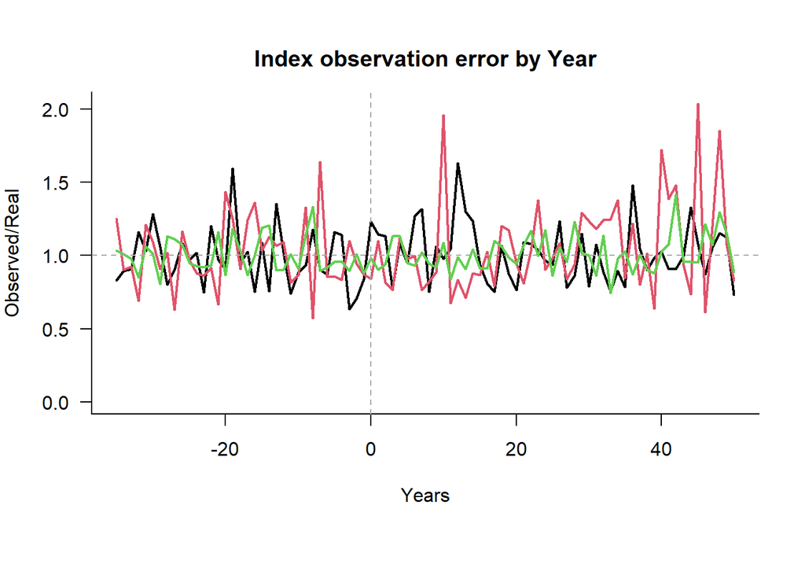

Plot showing an example true abundance index (blue) with 3 samples of index observation error and the hyper-stability/depletion parameter (`beta`):

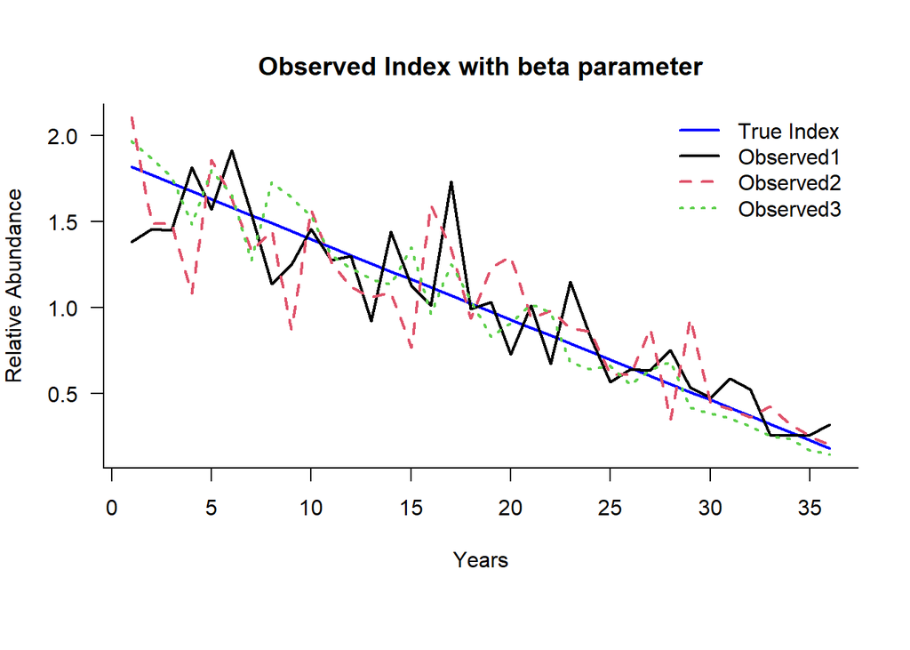